# DataScience_Capstone_Wk2

Joyce Lo

June 14, 2018

# Overview

The purpose of this week’s assignment is to show my progress towards the greater Capstone project - creation of a predictive text model. In this assignment, I will demonstrate my ability to a) import the data, b) cleanse and format the data, and c) conduct exploratory analysis like word count evaluation.

# Import Data

The data source is HC Corpora. For the project, I am using the three files in the “en_us” subfolder only.

```r
fileURL <- "https://d396qusza40orc.cloudfront.net/dsscapstone/dataset/Coursera-SwiftKey.zip"
if(!file.exists("data")){dir.create("data")}
download.file(fileURL, destfile = "./data/Coursera-SwiftKey.zip")
unzip(zipfile = "./data/Coursera-Swiftkey.zip", exdir = "./data")
```

# Read Files and Basic Summaries

We now read the files and explore some basic metrics like a) word count, line counts, file size of the three text files.

```r
library(ngram)
library(tm)
library(SnowballC)

twitter <- readLines("./data/final/en_us/en_US.twitter.txt")
blogs <- readLines("./data/final/en_us/en_US.blogs.txt")
news <- readLines("./data/final/en_us/en_US.news.txt")

text_summary <- data.frame('File' = c("Twitter", "Blogs", "News"),
                           'Count_of_Words' = sapply(list(twitter, blogs, news), function(x){format(wordcount(x), sep=" ", count.function=sum)}),
                           'Count_of_Lines' = sapply(list(twitter, blogs, news), function(x) {length(x)}),
                           'File_size' = sapply(list(twitter, blogs, news), function(x){format(object.size(x), "MB")})
                          )

text_summary
```

```
##      File Count_of_Words Count_of_Lines File_size
## 1 Twitter       30373543        2360148  301.4 Mb
## 2   Blogs       37334131         899288  248.5 Mb
## 3    News        2643969          77259   19.2 Mb
```

# Sampling, cleansing and formatting of data

## Sampling 10% of the lines

I shall use 10% of the lines for the training set.

```r
twittersample <- twitter[rbinom(length(twitter)*0.1, length(twitter), 0.1)]  #I just want 10% of lines
write.table(twittersample, file="./data/final/en_us/samples/twittersample_en_US.csv",row.names=FALSE,sep=",")
close(twitter)
rm(twitter) #remove this big file

blogssample <- blogs[rbinom(length(blogs)*0.1, length(blogs), 0.1)] #I just want 10% of the lines
write.table(blogssample, file="./data/final/en_us/samples/blogssample_en_US.csv", row.names=FALSE, sep=",")
close.connection(blogs)
rm(blogs)

newssample <- news[rbinom(length(news)*0.1, length(news), 0.1)]
write.table(newssample, file="./data/final/en_us/samples/newssample_en_US.csv", row.names=FALSE, sep=",")
close(news)
rm(news)
```

## Creating corpus

Now I shall create a corpus by aggregating these three sampled files

```r
#devtools::install_cran("tm", force=T)

mycorpus <- Corpus(DirSource("./data/final/en_us/samples"), readerControl = list(reader=readPlain, language = "en_US"))
meta(mycorpus)
meta(mycorpus[[1]], "id")
inspect(mycorpus[[2]])
```

## Formatting corpus

Once we have a corpus, it is appropriate to modify the contents by means of transformation. In this context, transformation includes stemming, stopword removal, whitespace elimination and case conversion. Transformations are done via the tm_map() function which applies (maps) a function to all elements of the corpus.

```r
# make eval = FALSE because this chunk only needs to be run once
#let's remove punctuations and numbers first
  mycorpus2 <- tm_map(mycorpus, removePunctuation)
  mycorpus2 <- tm_map(mycorpus2, removeNumbers)

  mycorpus2 <- tm_map(mycorpus2, content_transformer(tolower)) # let's transform texts into lower cases
  mycorpus2 <- tm_map(mycorpus2, removeWords, stopwords("english")) #Next, remove stop words like "and", "for", "in", etc.
  #mycorpus2 <- tm_map(mycorpus2, stemDocument, language = "english")#Now we do stemming - i.e. erase words' suffixes to retrieve their radicals.  e.g. 'engage', 'engaged', 'engaging' to 'engag'
  mycorpus2 <- tm_map(mycorpus2, stripWhitespace)#Now we eliminate extra whitespace
  mycorpus2 <- iconv(mycorpus2, "latin1", "ASCII", sub="")#Next, we get rid of non-ASCII characters

mycorpus2 <- Corpus(VectorSource(mycorpus2))#we need to turn this back to a corpus first

mycorpus2PTD <- tm_map(mycorpus2, PlainTextDocument)
writeCorpus(mycorpus2PTD, "./data/final/en_US/Not_stemmed", filenames = NULL) #Finally, write this training set corpus
```

# Count-based evaluation

Count-based evaluation is a simple, preliminary analysis whereby word(s) with the highest occurrence are rated as important. We shall create a term-document matrix which contains frequency of a specific term in the corpus. We will then create a histogram showing the most frequent word(s) in the corpus

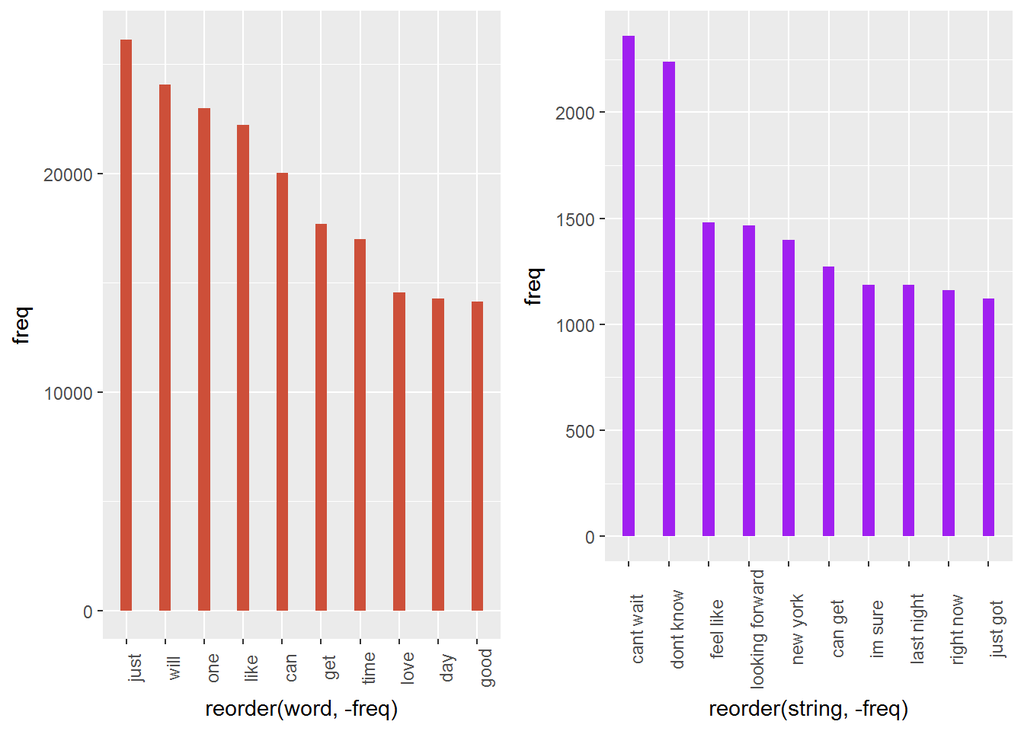

```r
#options(mc.cores=1)
#library(RWeka)
library(ggplot2)


newcorpus <- VCorpus(DirSource("./data/final/en_US/Not_stemmed")) #read the Corpus I saved

newcorpusTDM <- TermDocumentMatrix(newcorpus, control = list(stopwords= TRUE))
newcorpusTDM <- removeSparseTerms(newcorpusTDM, 0.999) #removing terms that occur in less than 1% of the Corpus
newcorpusTDM <- data.frame(word = newcorpusTDM$dimnames$Terms, freq = newcorpusTDM$v)
one_ordered <- plyr::arrange(newcorpusTDM, -freq) #I just want to see the top x in the bar graph
onegram_bar <- ggplot(one_ordered[1:10,], aes(x = reorder(word, - freq), y = freq)) + geom_bar(stat="identity", width=0.3, fill="tomato3") + theme(axis.text.x = element_text(angle=90))

#next, I want to see the most frequent STRING of words
#I tried RWeka many times to no avail - I ended up using ngram function from the tm package instead
#twogramTokenizer <- function(x) NGramTokenizer(x, Weka_control(min=2, max=2))

newcorpus <- as.VCorpus(newcorpus)
twogramTokenizer <- function(x) {unlist(lapply(ngrams(words(x), 2), paste, collapse = " "), use.names = FALSE)}
twogramTDM <- TermDocumentMatrix(newcorpus, control = list(tokenize = twogramTokenizer))
twogramTDM <- data.frame(string = twogramTDM$dimnames$Terms, freq = twogramTDM$v)
two_ordered <- plyr::arrange(twogramTDM, - freq)
twogram_bar <- ggplot(two_ordered[1:10,], aes(x=reorder(string, -freq), y=freq)) + geom_bar(stat="identity", width=0.3, fill="purple") + theme(axis.text.x = element_text(angle=90))


threegramTokenizer <- function(x) {unlist(lapply(ngrams(words(x), 3), paste, collapse = " "), use.names = FALSE)}
threegramTDM <- TermDocumentMatrix(newcorpus, control = list(tokenize = threegramTokenizer))
threegramTDM <- data.frame(string = threegramTDM$dimnames$Terms, freq = threegramTDM$v)
three_ordered <- plyr::arrange(threegramTDM, -freq)
threegram_bar <- ggplot(three_ordered[1:30,], aes(x=reorder(string,-freq), y=freq)) + geom_bar(stat = "identity", width=0.3, fill="green") + theme(axis.text.x = element_text(angle=90))

require(gridExtra)
grid.arrange(onegram_bar, twogram_bar, ncol=2)
```

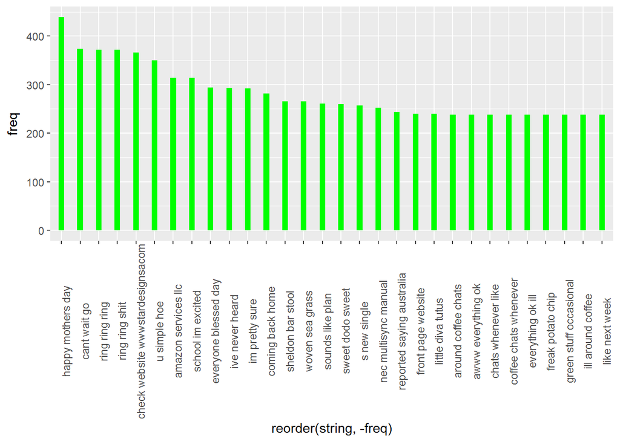

```r
threegram_bar
```

# Next steps

My next steps include the development of an interactive word-predictor on shiny.app. Here is my approach: a) parse the one-gram, two-gram, three-gram TDM dataframes into matrices with n+1 column. Each n column would contain the word and the n+1 column would contain the frequency b) interactive app will strip the word inputted by the user of any numbers, punctuations, white space, and etc. Afterwards, it will match the entered word against the first word of the the most frequently two-word phrase and return the second word. This also applies if user entered two words c) using the “stupid-backoff” approach, if no matches are found in the three-gram word matrix, R will retrieve to two-gram. If there are still no matches, then indicate so.

# Citation

I struggled with the RWeka package; specifically, it wouldn’t generate the matrix of two-word or three-word strings. I ended up researching online and found that “ngrams” function from the “tm” function is a sufficient alternative. I didn’t plagiarize - but I did use the codes suggested here: https://datascience.stackexchange.com/questions/18522/text-mining-in-r-without-rweka

I also found these two articles very helpful: * https://www.jstatsoft.org/article/view/v025i05 * https://cran.r-project.org/web/packages/tm/vignettes/tm.pdf